# Optimal Treatment Analysis

## Outcome Variable

**Outcome Variable:** ever_stunted

## Predictor Variables

**Intervention Variable:** perdiar6

**Adjustment Set:**

- arm
- sex
- W_mage
- meducyrs
- W_mhtcm
- W_mwtkg
- W_mbmi
- W_birthwt
- W_birthlen
- W_nrooms
- month
- brthmon
- impfloor
- impsan
- safeh20
- delta_W_mage
- delta_meducyrs
- delta_W_mhtcm
- delta_W_mwtkg
- delta_W_mbmi
- delta_W_birthwt
- delta_W_birthlen
- delta_W_nrooms
- delta_month
- delta_brthmon
- delta_impfloor
- delta_impsan
- delta_safeh20

## Stratifying Variables

The analysis was stratified on these variable(s):

- agecat
- studyid
- country

## Data Summary

| agecat | studyid | country | perdiar6 | ever_stunted | n_cell | n |
| --- | --- | --- | --- | --- | --- | --- |
| 0-24 months (no birth st.) | ki0047075b-MAL-ED | BANGLADESH | (0%, 5%] | 0 | 41 | 217 |
| 0-24 months (no birth st.) | ki0047075b-MAL-ED | BANGLADESH | (0%, 5%] | 1 | 44 | 217 |
| 0-24 months (no birth st.) | ki0047075b-MAL-ED | BANGLADESH | 0% | 0 | 36 | 217 |
| 0-24 months (no birth st.) | ki0047075b-MAL-ED | BANGLADESH | 0% | 1 | 36 | 217 |
| 0-24 months (no birth st.) | ki0047075b-MAL-ED | BANGLADESH | >5% | 0 | 27 | 217 |
| 0-24 months (no birth st.) | ki0047075b-MAL-ED | BANGLADESH | >5% | 1 | 33 | 217 |
| 0-24 months (no birth st.) | ki0047075b-MAL-ED | BRAZIL | (0%, 5%] | 0 | 12 | 208 |
| 0-24 months (no birth st.) | ki0047075b-MAL-ED | BRAZIL | (0%, 5%] | 1 | 2 | 208 |
| 0-24 months (no birth st.) | ki0047075b-MAL-ED | BRAZIL | 0% | 0 | 165 | 208 |
| 0-24 months (no birth st.) | ki0047075b-MAL-ED | BRAZIL | 0% | 1 | 27 | 208 |
| 0-24 months (no birth st.) | ki0047075b-MAL-ED | BRAZIL | >5% | 0 | 2 | 208 |
| 0-24 months (no birth st.) | ki0047075b-MAL-ED | BRAZIL | >5% | 1 | 0 | 208 |
| 0-24 months (no birth st.) | ki0047075b-MAL-ED | INDIA | (0%, 5%] | 0 | 54 | 209 |
| 0-24 months (no birth st.) | ki0047075b-MAL-ED | INDIA | (0%, 5%] | 1 | 52 | 209 |
| 0-24 months (no birth st.) | ki0047075b-MAL-ED | INDIA | 0% | 0 | 24 | 209 |
| 0-24 months (no birth st.) | ki0047075b-MAL-ED | INDIA | 0% | 1 | 25 | 209 |
| 0-24 months (no birth st.) | ki0047075b-MAL-ED | INDIA | >5% | 0 | 23 | 209 |
| 0-24 months (no birth st.) | ki0047075b-MAL-ED | INDIA | >5% | 1 | 31 | 209 |
| 0-24 months (no birth st.) | ki0047075b-MAL-ED | NEPAL | (0%, 5%] | 0 | 54 | 212 |
| 0-24 months (no birth st.) | ki0047075b-MAL-ED | NEPAL | (0%, 5%] | 1 | 14 | 212 |
| 0-24 months (no birth st.) | ki0047075b-MAL-ED | NEPAL | 0% | 0 | 54 | 212 |
| 0-24 months (no birth st.) | ki0047075b-MAL-ED | NEPAL | 0% | 1 | 20 | 212 |
| 0-24 months (no birth st.) | ki0047075b-MAL-ED | NEPAL | >5% | 0 | 49 | 212 |
| 0-24 months (no birth st.) | ki0047075b-MAL-ED | NEPAL | >5% | 1 | 21 | 212 |
| 0-24 months (no birth st.) | ki0047075b-MAL-ED | PERU | (0%, 5%] | 0 | 29 | 266 |
| 0-24 months (no birth st.) | ki0047075b-MAL-ED | PERU | (0%, 5%] | 1 | 51 | 266 |
| 0-24 months (no birth st.) | ki0047075b-MAL-ED | PERU | 0% | 0 | 37 | 266 |
| 0-24 months (no birth st.) | ki0047075b-MAL-ED | PERU | 0% | 1 | 40 | 266 |
| 0-24 months (no birth st.) | ki0047075b-MAL-ED | PERU | >5% | 0 | 49 | 266 |
| 0-24 months (no birth st.) | ki0047075b-MAL-ED | PERU | >5% | 1 | 60 | 266 |

[output cut: 258 more lines]

The following strata were considered:

- agecat: 0-24 months (no birth st.), studyid: ki0047075b-MAL-ED, country: BANGLADESH
- agecat: 0-24 months (no birth st.), studyid: ki0047075b-MAL-ED, country: BRAZIL
- agecat: 0-24 months (no birth st.), studyid: ki0047075b-MAL-ED, country: INDIA
- agecat: 0-24 months (no birth st.), studyid: ki0047075b-MAL-ED, country: NEPAL
- agecat: 0-24 months (no birth st.), studyid: ki0047075b-MAL-ED, country: PERU
- agecat: 0-24 months (no birth st.), studyid: ki0047075b-MAL-ED, country: SOUTH AFRICA
- agecat: 0-24 months (no birth st.), studyid: ki0047075b-MAL-ED, country: TANZANIA, UNITED REPUBLIC OF
- agecat: 0-24 months (no birth st.), studyid: ki1000109-ResPak, country: PAKISTAN
- agecat: 0-24 months (no birth st.), studyid: ki1017093-NIH-Birth, country: BANGLADESH
- agecat: 0-24 months (no birth st.), studyid: ki1017093b-PROVIDE, country: BANGLADESH
- agecat: 0-24 months (no birth st.), studyid: ki1017093c-NIH-Crypto, country: BANGLADESH
- agecat: 0-24 months (no birth st.), studyid: ki1114097-CMIN, country: BANGLADESH
- agecat: 0-24 months (no birth st.), studyid: ki1114097-CMIN, country: BRAZIL
- agecat: 0-24 months (no birth st.), studyid: ki1114097-CMIN, country: GUINEA-BISSAU
- agecat: 0-24 months (no birth st.), studyid: ki1114097-CMIN, country: PERU
- agecat: 0-24 months (no birth st.), studyid: ki1114097-CONTENT, country: PERU
- agecat: 0-6 months (no birth st.), studyid: ki0047075b-MAL-ED, country: BANGLADESH
- agecat: 0-6 months (no birth st.), studyid: ki0047075b-MAL-ED, country: BRAZIL
- agecat: 0-6 months (no birth st.), studyid: ki0047075b-MAL-ED, country: INDIA
- agecat: 0-6 months (no birth st.), studyid: ki0047075b-MAL-ED, country: NEPAL
- agecat: 0-6 months (no birth st.), studyid: ki0047075b-MAL-ED, country: PERU
- agecat: 0-6 months (no birth st.), studyid: ki0047075b-MAL-ED, country: SOUTH AFRICA
- agecat: 0-6 months (no birth st.), studyid: ki0047075b-MAL-ED, country: TANZANIA, UNITED REPUBLIC OF
- agecat: 0-6 months (no birth st.), studyid: ki1000109-ResPak, country: PAKISTAN
- agecat: 0-6 months (no birth st.), studyid: ki1017093-NIH-Birth, country: BANGLADESH
- agecat: 0-6 months (no birth st.), studyid: ki1017093b-PROVIDE, country: BANGLADESH
- agecat: 0-6 months (no birth st.), studyid: ki1017093c-NIH-Crypto, country: BANGLADESH
- agecat: 0-6 months (no birth st.), studyid: ki1114097-CMIN, country: BANGLADESH
- agecat: 0-6 months (no birth st.), studyid: ki1114097-CMIN, country: BRAZIL
- agecat: 0-6 months (no birth st.), studyid: ki1114097-CMIN, country: GUINEA-BISSAU
- agecat: 0-6 months (no birth st.), studyid: ki1114097-CMIN, country: PERU
- agecat: 0-6 months (no birth st.), studyid: ki1114097-CONTENT, country: PERU
- agecat: 6-24 months, studyid: ki0047075b-MAL-ED, country: BANGLADESH
- agecat: 6-24 months, studyid: ki0047075b-MAL-ED, country: BRAZIL
- agecat: 6-24 months, studyid: ki0047075b-MAL-ED, country: INDIA
- agecat: 6-24 months, studyid: ki0047075b-MAL-ED, country: NEPAL
- agecat: 6-24 months, studyid: ki0047075b-MAL-ED, country: PERU
- agecat: 6-24 months, studyid: ki0047075b-MAL-ED, country: SOUTH AFRICA
- agecat: 6-24 months, studyid: ki0047075b-MAL-ED, country: TANZANIA, UNITED REPUBLIC OF
- agecat: 6-24 months, studyid: ki1000109-ResPak, country: PAKISTAN
- agecat: 6-24 months, studyid: ki1017093-NIH-Birth, country: BANGLADESH
- agecat: 6-24 months, studyid: ki1017093b-PROVIDE, country: BANGLADESH
- agecat: 6-24 months, studyid: ki1017093c-NIH-Crypto, country: BANGLADESH
- agecat: 6-24 months, studyid: ki1114097-CMIN, country: BANGLADESH
- agecat: 6-24 months, studyid: ki1114097-CMIN, country: BRAZIL
- agecat: 6-24 months, studyid: ki1114097-CMIN, country: GUINEA-BISSAU
- agecat: 6-24 months, studyid: ki1114097-CMIN, country: PERU
- agecat: 6-24 months, studyid: ki1114097-CONTENT, country: PERU

### Dropped Strata

Some strata were dropped due to rare outcomes:

- agecat: 0-24 months (no birth st.), studyid: ki0047075b-MAL-ED, country: BRAZIL
- agecat: 0-24 months (no birth st.), studyid: ki0047075b-MAL-ED, country: SOUTH AFRICA
- agecat: 0-6 months (no birth st.), studyid: ki0047075b-MAL-ED, country: BRAZIL
- agecat: 0-6 months (no birth st.), studyid: ki0047075b-MAL-ED, country: NEPAL
- agecat: 0-6 months (no birth st.), studyid: ki0047075b-MAL-ED, country: SOUTH AFRICA
- agecat: 0-6 months (no birth st.), studyid: ki1114097-CMIN, country: BRAZIL
- agecat: 0-6 months (no birth st.), studyid: ki1114097-CMIN, country: GUINEA-BISSAU
- agecat: 0-6 months (no birth st.), studyid: ki1114097-CONTENT, country: PERU
- agecat: 6-24 months, studyid: ki0047075b-MAL-ED, country: BRAZIL
- agecat: 6-24 months, studyid: ki0047075b-MAL-ED, country: SOUTH AFRICA
- agecat: 6-24 months, studyid: ki1000109-ResPak, country: PAKISTAN
- agecat: 6-24 months, studyid: ki1114097-CONTENT, country: PERU

## Methods Detail

We’re interested in the causal parameters $E[Y_a]$ for all values of $a \in \mathcal{A}$. These parameters represent the mean outcome if, possibly contrary to fact, we intervened to set all units to have $A=a$. Under the randomization and positivity assumptions, these are identified by the statistical parameters $\psi_a=E_W[E_{Y|A,W}(Y|A=a,W)]$. In addition, we’re interested in the mean of $Y$, $E[Y]$ under no intervention (the observed mean). We will estimate these parameters by using SuperLearner to fit the relevant likelihood factors – $E_{Y|A,W}(Y|A=a,W)$ and $p(A=a|W)$, and then updating our likelihood fit using a joint TMLE.

For unadjusted analyses ($W=\{\}$), initial likelihoods were estimated using Lrnr_glm to estimate the simple $E(Y|A)$ and Lrnr_mean to estimate $p(A)$. For adjusted analyses, a small library containing Lrnr_glmnet, Lrnr_xgboost, and Lrnr_mean was used.

Having estimated these parameters, we will then use the delta method to estimate relative risks and attributable risks relative to a prespecified baseline level of $A$.

# Results Detail

## Results Plots

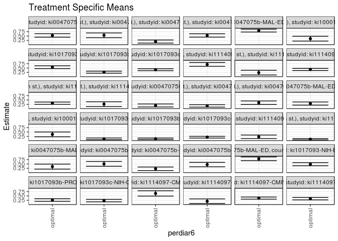

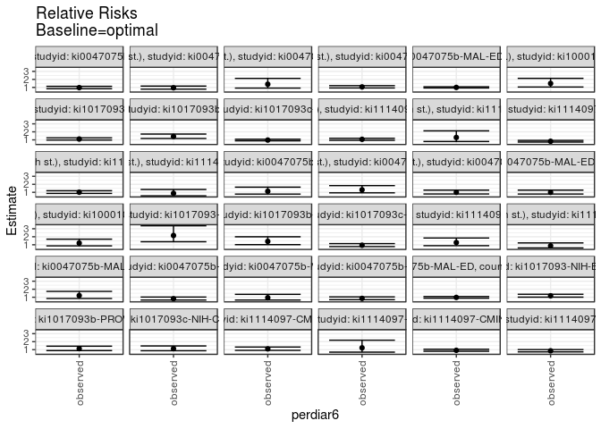

## Results Table

### Parameter: TSM

| agecat | studyid | country | intervention_level | baseline_level | estimate | ci_lower | ci_upper |
| --- | --- | --- | --- | --- | --- | --- | --- |
| 0-24 months (no birth st.) | ki0047075b-MAL-ED | BANGLADESH | optimal | NA | 0.5359270 | 0.4365067 | 0.6353474 |
| 0-24 months (no birth st.) | ki0047075b-MAL-ED | INDIA | optimal | NA | 0.5433046 | 0.4065616 | 0.6800476 |
| 0-24 months (no birth st.) | ki0047075b-MAL-ED | NEPAL | optimal | NA | 0.1859223 | 0.0963039 | 0.2755408 |
| 0-24 months (no birth st.) | ki0047075b-MAL-ED | PERU | optimal | NA | 0.5340181 | 0.4389943 | 0.6290420 |
| 0-24 months (no birth st.) | ki0047075b-MAL-ED | TANZANIA, UNITED REPUBLIC OF | optimal | NA | 0.8132142 | 0.7319136 | 0.8945148 |
| 0-24 months (no birth st.) | ki1000109-ResPak | PAKISTAN | optimal | NA | 0.3497779 | 0.2109964 | 0.4885594 |
| 0-24 months (no birth st.) | ki1017093-NIH-Birth | BANGLADESH | optimal | NA | 0.5472795 | 0.4668045 | 0.6277545 |
| 0-24 months (no birth st.) | ki1017093b-PROVIDE | BANGLADESH | optimal | NA | 0.2633966 | 0.2042032 | 0.3225899 |
| 0-24 months (no birth st.) | ki1017093c-NIH-Crypto | BANGLADESH | optimal | NA | 0.4035077 | 0.3481315 | 0.4588840 |
| 0-24 months (no birth st.) | ki1114097-CMIN | BANGLADESH | optimal | NA | 0.7077619 | 0.5977687 | 0.8177551 |
| 0-24 months (no birth st.) | ki1114097-CMIN | BRAZIL | optimal | NA | 0.2365362 | 0.0991717 | 0.3739007 |
| 0-24 months (no birth st.) | ki1114097-CMIN | GUINEA-BISSAU | optimal | NA | 0.4184184 | 0.3570771 | 0.4797596 |
| 0-24 months (no birth st.) | ki1114097-CMIN | PERU | optimal | NA | 0.3183387 | 0.2544511 | 0.3822262 |
| 0-24 months (no birth st.) | ki1114097-CONTENT | PERU | optimal | NA | 0.2624023 | 0.1261092 | 0.3986954 |
| 0-6 months (no birth st.) | ki0047075b-MAL-ED | BANGLADESH | optimal | NA | 0.1875824 | 0.1009720 | 0.2741928 |
| 0-6 months (no birth st.) | ki0047075b-MAL-ED | INDIA | optimal | NA | 0.1606543 | 0.0901500 | 0.2311587 |
| 0-6 months (no birth st.) | ki0047075b-MAL-ED | PERU | optimal | NA | 0.3446480 | 0.2440607 | 0.4452354 |
| 0-6 months (no birth st.) | ki0047075b-MAL-ED | TANZANIA, UNITED REPUBLIC OF | optimal | NA | 0.2965660 | 0.2055361 | 0.3875958 |
| 0-6 months (no birth st.) | ki1000109-ResPak | PAKISTAN | optimal | NA | 0.3621241 | 0.2236128 | 0.5006354 |
| 0-6 months (no birth st.) | ki1017093-NIH-Birth | BANGLADESH | optimal | NA | 0.1063138 | 0.0551523 | 0.1574753 |
| 0-6 months (no birth st.) | ki1017093b-PROVIDE | BANGLADESH | optimal | NA | 0.1118798 | 0.0689477 | 0.1548118 |
| 0-6 months (no birth st.) | ki1017093c-NIH-Crypto | BANGLADESH | optimal | NA | 0.2017096 | 0.1522775 | 0.2511418 |
| 0-6 months (no birth st.) | ki1114097-CMIN | BANGLADESH | optimal | NA | 0.2234011 | 0.1224400 | 0.3243622 |
| 0-6 months (no birth st.) | ki1114097-CMIN | PERU | optimal | NA | 0.0858794 | 0.0473459 | 0.1244129 |
| 6-24 months | ki0047075b-MAL-ED | BANGLADESH | optimal | NA | 0.3492045 | 0.2046425 | 0.4937664 |
| 6-24 months | ki0047075b-MAL-ED | INDIA | optimal | NA | 0.5068025 | 0.3688406 | 0.6447644 |
| 6-24 months | ki0047075b-MAL-ED | NEPAL | optimal | NA | 0.2240276 | 0.1222973 | 0.3257579 |
| 6-24 months | ki0047075b-MAL-ED | PERU | optimal | NA | 0.4645296 | 0.3374209 | 0.5916383 |
| 6-24 months | ki0047075b-MAL-ED | TANZANIA, UNITED REPUBLIC OF | optimal | NA | 0.7968474 | 0.6897646 | 0.9039302 |
| 6-24 months | ki1017093-NIH-Birth | BANGLADESH | optimal | NA | 0.4876267 | 0.3977605 | 0.5774930 |
| 6-24 months | ki1017093b-PROVIDE | BANGLADESH | optimal | NA | 0.2656658 | 0.1903059 | 0.3410258 |
| 6-24 months | ki1017093c-NIH-Crypto | BANGLADESH | optimal | NA | 0.2331093 | 0.1627555 | 0.3034631 |
| 6-24 months | ki1114097-CMIN | BANGLADESH | optimal | NA | 0.6457346 | 0.4923254 | 0.7991439 |
| 6-24 months | ki1114097-CMIN | BRAZIL | optimal | NA | 0.1953462 | 0.0622266 | 0.3284658 |
| 6-24 months | ki1114097-CMIN | GUINEA-BISSAU | optimal | NA | 0.3769400 | 0.3162549 | 0.4376251 |
| 6-24 months | ki1114097-CMIN | PERU | optimal | NA | 0.3431799 | 0.2733089 | 0.4130509 |

### Parameter: E(Y)

| agecat | studyid | country | intervention_level | baseline_level | estimate | ci_lower | ci_upper |
| --- | --- | --- | --- | --- | --- | --- | --- |
| 0-24 months (no birth st.) | ki0047075b-MAL-ED | BANGLADESH | observed | NA | 0.5207373 | 0.4541154 | 0.5873593 |
| 0-24 months (no birth st.) | ki0047075b-MAL-ED | INDIA | observed | NA | 0.5167464 | 0.4488350 | 0.5846578 |
| 0-24 months (no birth st.) | ki0047075b-MAL-ED | NEPAL | observed | NA | 0.2594340 | 0.2002911 | 0.3185768 |
| 0-24 months (no birth st.) | ki0047075b-MAL-ED | PERU | observed | NA | 0.5676692 | 0.5080232 | 0.6273151 |
| 0-24 months (no birth st.) | ki0047075b-MAL-ED | TANZANIA, UNITED REPUBLIC OF | observed | NA | 0.8127854 | 0.7610035 | 0.8645672 |
| 0-24 months (no birth st.) | ki1000109-ResPak | PAKISTAN | observed | NA | 0.5223881 | 0.4531624 | 0.5916138 |
| 0-24 months (no birth st.) | ki1017093-NIH-Birth | BANGLADESH | observed | NA | 0.6041667 | 0.5624147 | 0.6459187 |
| 0-24 months (no birth st.) | ki1017093b-PROVIDE | BANGLADESH | observed | NA | 0.3753943 | 0.3376725 | 0.4131162 |
| 0-24 months (no birth st.) | ki1017093c-NIH-Crypto | BANGLADESH | observed | NA | 0.3935681 | 0.3560687 | 0.4310676 |
| 0-24 months (no birth st.) | ki1114097-CMIN | BANGLADESH | observed | NA | 0.7559524 | 0.6908084 | 0.8210964 |
| 0-24 months (no birth st.) | ki1114097-CMIN | BRAZIL | observed | NA | 0.3070175 | 0.2219720 | 0.3920631 |
| 0-24 months (no birth st.) | ki1114097-CMIN | GUINEA-BISSAU | observed | NA | 0.3443038 | 0.3111501 | 0.3774575 |
| 0-24 months (no birth st.) | ki1114097-CMIN | PERU | observed | NA | 0.3229167 | 0.2875370 | 0.3582963 |
| 0-24 months (no birth st.) | ki1114097-CONTENT | PERU | observed | NA | 0.2284264 | 0.1696529 | 0.2871999 |
| 0-6 months (no birth st.) | ki0047075b-MAL-ED | BANGLADESH | observed | NA | 0.2119816 | 0.1574763 | 0.2664868 |
| 0-6 months (no birth st.) | ki0047075b-MAL-ED | INDIA | observed | NA | 0.2105263 | 0.1551227 | 0.2659300 |
| 0-6 months (no birth st.) | ki0047075b-MAL-ED | PERU | observed | NA | 0.3458647 | 0.2885967 | 0.4031327 |
| 0-6 months (no birth st.) | ki0047075b-MAL-ED | TANZANIA, UNITED REPUBLIC OF | observed | NA | 0.2968037 | 0.2361590 | 0.3574483 |
| 0-6 months (no birth st.) | ki1000109-ResPak | PAKISTAN | observed | NA | 0.4378109 | 0.3690538 | 0.5065681 |
| 0-6 months (no birth st.) | ki1017093-NIH-Birth | BANGLADESH | observed | NA | 0.2291667 | 0.1932828 | 0.2650505 |
| 0-6 months (no birth st.) | ki1017093b-PROVIDE | BANGLADESH | observed | NA | 0.1593060 | 0.1307970 | 0.1878149 |
| 0-6 months (no birth st.) | ki1017093c-NIH-Crypto | BANGLADESH | observed | NA | 0.1898928 | 0.1597870 | 0.2199986 |
| 0-6 months (no birth st.) | ki1114097-CMIN | BANGLADESH | observed | NA | 0.2857143 | 0.2171983 | 0.3542303 |
| 0-6 months (no birth st.) | ki1114097-CMIN | PERU | observed | NA | 0.0744681 | 0.0543935 | 0.0945427 |
| 6-24 months | ki0047075b-MAL-ED | BANGLADESH | observed | NA | 0.4213836 | 0.3443902 | 0.4983771 |
| 6-24 months | ki0047075b-MAL-ED | INDIA | observed | NA | 0.4129032 | 0.3351414 | 0.4906651 |
| 6-24 months | ki0047075b-MAL-ED | NEPAL | observed | NA | 0.2102564 | 0.1529155 | 0.2675974 |
| 6-24 months | ki0047075b-MAL-ED | PERU | observed | NA | 0.3959732 | 0.3171819 | 0.4747644 |
| 6-24 months | ki0047075b-MAL-ED | TANZANIA, UNITED REPUBLIC OF | observed | NA | 0.7793103 | 0.7115754 | 0.8470453 |
| 6-24 months | ki1017093-NIH-Birth | BANGLADESH | observed | NA | 0.5739130 | 0.5216565 | 0.6261696 |
| 6-24 months | ki1017093b-PROVIDE | BANGLADESH | observed | NA | 0.2997812 | 0.2577294 | 0.3418330 |
| 6-24 months | ki1017093c-NIH-Crypto | BANGLADESH | observed | NA | 0.2628458 | 0.2244546 | 0.3012371 |
| 6-24 months | ki1114097-CMIN | BANGLADESH | observed | NA | 0.7117117 | 0.6270636 | 0.7963598 |
| 6-24 months | ki1114097-CMIN | BRAZIL | observed | NA | 0.2403846 | 0.1578607 | 0.3229085 |
| 6-24 months | ki1114097-CMIN | GUINEA-BISSAU | observed | NA | 0.3467532 | 0.3131150 | 0.3803915 |
| 6-24 months | ki1114097-CMIN | PERU | observed | NA | 0.2940171 | 0.2570662 | 0.3309680 |

### Parameter: RR

| agecat | studyid | country | intervention_level | baseline_level | estimate | ci_lower | ci_upper |
| --- | --- | --- | --- | --- | --- | --- | --- |
| 0-24 months (no birth st.) | ki0047075b-MAL-ED | BANGLADESH | observed | optimal | 0.9716571 | 0.8330780 | 1.1332883 |
| 0-24 months (no birth st.) | ki0047075b-MAL-ED | INDIA | observed | optimal | 0.9511173 | 0.7787348 | 1.1616590 |
| 0-24 months (no birth st.) | ki0047075b-MAL-ED | NEPAL | observed | optimal | 1.3953889 | 0.9157700 | 2.1262001 |
| 0-24 months (no birth st.) | ki0047075b-MAL-ED | PERU | observed | optimal | 1.0630148 | 0.9265174 | 1.2196213 |
| 0-24 months (no birth st.) | ki0047075b-MAL-ED | TANZANIA, UNITED REPUBLIC OF | observed | optimal | 0.9994727 | 0.9271996 | 1.0773792 |
| 0-24 months (no birth st.) | ki1000109-ResPak | PAKISTAN | observed | optimal | 1.4934850 | 1.0470518 | 2.1302647 |
| 0-24 months (no birth st.) | ki1017093-NIH-Birth | BANGLADESH | observed | optimal | 1.1039453 | 0.9749232 | 1.2500424 |
| 0-24 months (no birth st.) | ki1017093b-PROVIDE | BANGLADESH | observed | optimal | 1.4252058 | 1.1785440 | 1.7234922 |
| 0-24 months (no birth st.) | ki1017093c-NIH-Crypto | BANGLADESH | observed | optimal | 0.9753671 | 0.8842890 | 1.0758258 |
| 0-24 months (no birth st.) | ki1114097-CMIN | BANGLADESH | observed | optimal | 1.0680886 | 0.9509255 | 1.1996872 |
| 0-24 months (no birth st.) | ki1114097-CMIN | BRAZIL | observed | optimal | 1.2979727 | 0.7927486 | 2.1251797 |
| 0-24 months (no birth st.) | ki1114097-CMIN | GUINEA-BISSAU | observed | optimal | 0.8228697 | 0.7275821 | 0.9306366 |
| 0-24 months (no birth st.) | ki1114097-CMIN | PERU | observed | optimal | 1.0143809 | 0.8592971 | 1.1974539 |
| 0-24 months (no birth st.) | ki1114097-CONTENT | PERU | observed | optimal | 0.8705198 | 0.5590590 | 1.3555005 |
| 0-6 months (no birth st.) | ki0047075b-MAL-ED | BANGLADESH | observed | optimal | 1.1300718 | 0.7767109 | 1.6441925 |
| 0-6 months (no birth st.) | ki0047075b-MAL-ED | INDIA | observed | optimal | 1.3104304 | 0.9351837 | 1.8362466 |
| 0-6 months (no birth st.) | ki0047075b-MAL-ED | PERU | observed | optimal | 1.0035300 | 0.7920327 | 1.2715036 |
| 0-6 months (no birth st.) | ki0047075b-MAL-ED | TANZANIA, UNITED REPUBLIC OF | observed | optimal | 1.0008015 | 0.7867966 | 1.2730146 |
| 0-6 months (no birth st.) | ki1000109-ResPak | PAKISTAN | observed | optimal | 1.2090079 | 0.8606559 | 1.6983559 |
| 0-6 months (no birth st.) | ki1017093-NIH-Birth | BANGLADESH | observed | optimal | 2.1555692 | 1.3797443 | 3.3676375 |
| 0-6 months (no birth st.) | ki1017093b-PROVIDE | BANGLADESH | observed | optimal | 1.4239036 | 1.0156667 | 1.9962273 |
| 0-6 months (no birth st.) | ki1017093c-NIH-Crypto | BANGLADESH | observed | optimal | 0.9414166 | 0.7737998 | 1.1453417 |
| 0-6 months (no birth st.) | ki1114097-CMIN | BANGLADESH | observed | optimal | 1.2789297 | 0.8862158 | 1.8456689 |
| 0-6 months (no birth st.) | ki1114097-CMIN | PERU | observed | optimal | 0.8671237 | 0.6106261 | 1.2313649 |
| 6-24 months | ki0047075b-MAL-ED | BANGLADESH | observed | optimal | 1.2066961 | 0.8416610 | 1.7300498 |
| 6-24 months | ki0047075b-MAL-ED | INDIA | observed | optimal | 0.8147222 | 0.6508515 | 1.0198520 |
| 6-24 months | ki0047075b-MAL-ED | NEPAL | observed | optimal | 0.9385289 | 0.6478428 | 1.3596455 |
| 6-24 months | ki0047075b-MAL-ED | PERU | observed | optimal | 0.8524175 | 0.6951524 | 1.0452609 |
| 6-24 months | ki0047075b-MAL-ED | TANZANIA, UNITED REPUBLIC OF | observed | optimal | 0.9779920 | 0.8798401 | 1.0870934 |
| 6-24 months | ki1017093-NIH-Birth | BANGLADESH | observed | optimal | 1.1769516 | 1.0117347 | 1.3691485 |
| 6-24 months | ki1017093b-PROVIDE | BANGLADESH | observed | optimal | 1.1284145 | 0.8862711 | 1.4367154 |
| 6-24 months | ki1017093c-NIH-Crypto | BANGLADESH | observed | optimal | 1.1275647 | 0.8670499 | 1.4663542 |
| 6-24 months | ki1114097-CMIN | BANGLADESH | observed | optimal | 1.1021737 | 0.9133655 | 1.3300116 |
| 6-24 months | ki1114097-CMIN | BRAZIL | observed | optimal | 1.2305569 | 0.6933187 | 2.1840898 |
| 6-24 months | ki1114097-CMIN | GUINEA-BISSAU | observed | optimal | 0.9199163 | 0.8044869 | 1.0519077 |
| 6-24 months | ki1114097-CMIN | PERU | observed | optimal | 0.8567433 | 0.7270285 | 1.0096016 |

### Parameter: PAR

| agecat | studyid | country | intervention_level | baseline_level | estimate | ci_lower | ci_upper |
| --- | --- | --- | --- | --- | --- | --- | --- |
| 0-24 months (no birth st.) | ki0047075b-MAL-ED | BANGLADESH | optimal | NA | -0.0151897 | -0.0974004 | 0.0670210 |
| 0-24 months (no birth st.) | ki0047075b-MAL-ED | INDIA | optimal | NA | -0.0265582 | -0.1356605 | 0.0825442 |
| 0-24 months (no birth st.) | ki0047075b-MAL-ED | NEPAL | optimal | NA | 0.0735116 | -0.0063091 | 0.1533324 |
| 0-24 months (no birth st.) | ki0047075b-MAL-ED | PERU | optimal | NA | 0.0336510 | -0.0396124 | 0.1069145 |
| 0-24 months (no birth st.) | ki0047075b-MAL-ED | TANZANIA, UNITED REPUBLIC OF | optimal | NA | -0.0004288 | -0.0614687 | 0.0606110 |
| 0-24 months (no birth st.) | ki1000109-ResPak | PAKISTAN | optimal | NA | 0.1726102 | 0.0496328 | 0.2955875 |
| 0-24 months (no birth st.) | ki1017093-NIH-Birth | BANGLADESH | optimal | NA | 0.0568872 | -0.0109256 | 0.1246999 |
| 0-24 months (no birth st.) | ki1017093b-PROVIDE | BANGLADESH | optimal | NA | 0.1119977 | 0.0619426 | 0.1620529 |
| 0-24 months (no birth st.) | ki1017093c-NIH-Crypto | BANGLADESH | optimal | NA | -0.0099396 | -0.0495142 | 0.0296350 |
| 0-24 months (no birth st.) | ki1114097-CMIN | BANGLADESH | optimal | NA | 0.0481905 | -0.0334784 | 0.1298594 |
| 0-24 months (no birth st.) | ki1114097-CMIN | BRAZIL | optimal | NA | 0.0704813 | -0.0465320 | 0.1874947 |
| 0-24 months (no birth st.) | ki1114097-CMIN | GUINEA-BISSAU | optimal | NA | -0.0741146 | -0.1252217 | -0.0230075 |
| 0-24 months (no birth st.) | ki1114097-CMIN | PERU | optimal | NA | 0.0045780 | -0.0482326 | 0.0573886 |
| 0-24 months (no birth st.) | ki1114097-CONTENT | PERU | optimal | NA | -0.0339759 | -0.1507910 | 0.0828392 |
| 0-6 months (no birth st.) | ki0047075b-MAL-ED | BANGLADESH | optimal | NA | 0.0243992 | -0.0460074 | 0.0948058 |
| 0-6 months (no birth st.) | ki0047075b-MAL-ED | INDIA | optimal | NA | 0.0498720 | -0.0052058 | 0.1049498 |
| 0-6 months (no birth st.) | ki0047075b-MAL-ED | PERU | optimal | NA | 0.0012166 | -0.0803492 | 0.0827824 |
| 0-6 months (no birth st.) | ki0047075b-MAL-ED | TANZANIA, UNITED REPUBLIC OF | optimal | NA | 0.0002377 | -0.0711148 | 0.0715902 |
| 0-6 months (no birth st.) | ki1000109-ResPak | PAKISTAN | optimal | NA | 0.0756868 | -0.0472758 | 0.1986494 |
| 0-6 months (no birth st.) | ki1017093-NIH-Birth | BANGLADESH | optimal | NA | 0.1228529 | 0.0727002 | 0.1730056 |
| 0-6 months (no birth st.) | ki1017093b-PROVIDE | BANGLADESH | optimal | NA | 0.0474262 | 0.0087597 | 0.0860928 |
| 0-6 months (no birth st.) | ki1017093c-NIH-Crypto | BANGLADESH | optimal | NA | -0.0118168 | -0.0513048 | 0.0276711 |
| 0-6 months (no birth st.) | ki1114097-CMIN | BANGLADESH | optimal | NA | 0.0623132 | -0.0199620 | 0.1445884 |
| 0-6 months (no birth st.) | ki1114097-CMIN | PERU | optimal | NA | -0.0114113 | -0.0417773 | 0.0189546 |
| 6-24 months | ki0047075b-MAL-ED | BANGLADESH | optimal | NA | 0.0721792 | -0.0534964 | 0.1978548 |
| 6-24 months | ki0047075b-MAL-ED | INDIA | optimal | NA | -0.0938993 | -0.2066126 | 0.0188140 |
| 6-24 months | ki0047075b-MAL-ED | NEPAL | optimal | NA | -0.0137712 | -0.0967921 | 0.0692497 |
| 6-24 months | ki0047075b-MAL-ED | PERU | optimal | NA | -0.0685564 | -0.1632159 | 0.0261030 |
| 6-24 months | ki0047075b-MAL-ED | TANZANIA, UNITED REPUBLIC OF | optimal | NA | -0.0175370 | -0.1017699 | 0.0666959 |
| 6-24 months | ki1017093-NIH-Birth | BANGLADESH | optimal | NA | 0.0862863 | 0.0129065 | 0.1596661 |
| 6-24 months | ki1017093b-PROVIDE | BANGLADESH | optimal | NA | 0.0341154 | -0.0300610 | 0.0982917 |
| 6-24 months | ki1017093c-NIH-Crypto | BANGLADESH | optimal | NA | 0.0297365 | -0.0316182 | 0.0910912 |
| 6-24 months | ki1114097-CMIN | BANGLADESH | optimal | NA | 0.0659771 | -0.0543817 | 0.1863359 |
| 6-24 months | ki1114097-CMIN | BRAZIL | optimal | NA | 0.0450384 | -0.0674226 | 0.1574994 |
| 6-24 months | ki1114097-CMIN | GUINEA-BISSAU | optimal | NA | -0.0301868 | -0.0806456 | 0.0202720 |
| 6-24 months | ki1114097-CMIN | PERU | optimal | NA | -0.0491628 | -0.1056483 | 0.0073227 |

### Parameter: PAF

| agecat | studyid | country | intervention_level | baseline_level | estimate | ci_lower | ci_upper |
| --- | --- | --- | --- | --- | --- | --- | --- |
| 0-24 months (no birth st.) | ki0047075b-MAL-ED | BANGLADESH | optimal | NA | -0.0291696 | -0.2003677 | 0.1176120 |
| 0-24 months (no birth st.) | ki0047075b-MAL-ED | INDIA | optimal | NA | -0.0513950 | -0.2841343 | 0.1391621 |
| 0-24 months (no birth st.) | ki0047075b-MAL-ED | NEPAL | optimal | NA | 0.2833539 | -0.0919772 | 0.5296774 |
| 0-24 months (no birth st.) | ki0047075b-MAL-ED | PERU | optimal | NA | 0.0592793 | -0.0793105 | 0.1800734 |
| 0-24 months (no birth st.) | ki0047075b-MAL-ED | TANZANIA, UNITED REPUBLIC OF | optimal | NA | -0.0005276 | -0.0785164 | 0.0718217 |
| 0-24 months (no birth st.) | ki1000109-ResPak | PAKISTAN | optimal | NA | 0.3304252 | 0.0449374 | 0.5305748 |
| 0-24 months (no birth st.) | ki1017093-NIH-Birth | BANGLADESH | optimal | NA | 0.0941580 | -0.0257219 | 0.2000271 |
| 0-24 months (no birth st.) | ki1017093b-PROVIDE | BANGLADESH | optimal | NA | 0.2983469 | 0.1514954 | 0.4197827 |
| 0-24 months (no birth st.) | ki1017093c-NIH-Crypto | BANGLADESH | optimal | NA | -0.0252550 | -0.1308521 | 0.0704815 |
| 0-24 months (no birth st.) | ki1114097-CMIN | BANGLADESH | optimal | NA | 0.0637480 | -0.0516071 | 0.1664494 |
| 0-24 months (no birth st.) | ki1114097-CMIN | BRAZIL | optimal | NA | 0.2295678 | -0.2614339 | 0.5294515 |
| 0-24 months (no birth st.) | ki1114097-CMIN | GUINEA-BISSAU | optimal | NA | -0.2152593 | -0.3744154 | -0.0745333 |
| 0-24 months (no birth st.) | ki1114097-CMIN | PERU | optimal | NA | 0.0141770 | -0.1637419 | 0.1648948 |
| 0-24 months (no birth st.) | ki1114097-CONTENT | PERU | optimal | NA | -0.1487390 | -0.7887200 | 0.2622651 |
| 0-6 months (no birth st.) | ki0047075b-MAL-ED | BANGLADESH | optimal | NA | 0.1151005 | -0.2874803 | 0.3917987 |
| 0-6 months (no birth st.) | ki0047075b-MAL-ED | INDIA | optimal | NA | 0.2368919 | -0.0693086 | 0.4554108 |
| 0-6 months (no birth st.) | ki0047075b-MAL-ED | PERU | optimal | NA | 0.0035176 | -0.2625741 | 0.2135296 |
| 0-6 months (no birth st.) | ki0047075b-MAL-ED | TANZANIA, UNITED REPUBLIC OF | optimal | NA | 0.0008008 | -0.2709765 | 0.2144631 |
| 0-6 months (no birth st.) | ki1000109-ResPak | PAKISTAN | optimal | NA | 0.1728755 | -0.1619045 | 0.4111953 |
| 0-6 months (no birth st.) | ki1017093-NIH-Birth | BANGLADESH | optimal | NA | 0.5360854 | 0.2752280 | 0.7030559 |
| 0-6 months (no birth st.) | ki1017093b-PROVIDE | BANGLADESH | optimal | NA | 0.2977053 | 0.0154250 | 0.4990550 |
| 0-6 months (no birth st.) | ki1017093c-NIH-Crypto | BANGLADESH | optimal | NA | -0.0622290 | -0.2923240 | 0.1268981 |
| 0-6 months (no birth st.) | ki1114097-CMIN | BANGLADESH | optimal | NA | 0.2180962 | -0.1283933 | 0.4581910 |
| 0-6 months (no birth st.) | ki1114097-CMIN | PERU | optimal | NA | -0.1532380 | -0.6376634 | 0.1878930 |
| 6-24 months | ki0047075b-MAL-ED | BANGLADESH | optimal | NA | 0.1712909 | -0.1881268 | 0.4219820 |
| 6-24 months | ki0047075b-MAL-ED | INDIA | optimal | NA | -0.2274123 | -0.5364488 | 0.0194655 |
| 6-24 months | ki0047075b-MAL-ED | NEPAL | optimal | NA | -0.0654973 | -0.5435844 | 0.2645142 |
| 6-24 months | ki0047075b-MAL-ED | PERU | optimal | NA | -0.1731340 | -0.4385336 | 0.0433011 |
| 6-24 months | ki0047075b-MAL-ED | TANZANIA, UNITED REPUBLIC OF | optimal | NA | -0.0225032 | -0.1365702 | 0.0801158 |
| 6-24 months | ki1017093-NIH-Birth | BANGLADESH | optimal | NA | 0.1503474 | 0.0115986 | 0.2696190 |
| 6-24 months | ki1017093b-PROVIDE | BANGLADESH | optimal | NA | 0.1138008 | -0.1283229 | 0.3039679 |
| 6-24 months | ki1017093c-NIH-Crypto | BANGLADESH | optimal | NA | 0.1131329 | -0.1533362 | 0.3180365 |
| 6-24 months | ki1114097-CMIN | BANGLADESH | optimal | NA | 0.0927020 | -0.0948519 | 0.2481269 |
| 6-24 months | ki1114097-CMIN | BRAZIL | optimal | NA | 0.1873598 | -0.4423381 | 0.5421434 |
| 6-24 months | ki1114097-CMIN | GUINEA-BISSAU | optimal | NA | -0.0870555 | -0.2430283 | 0.0493462 |
| 6-24 months | ki1114097-CMIN | PERU | optimal | NA | -0.1672107 | -0.3754619 | 0.0095103 |